# CHAPTER A21

### A21.5 3本ストリンガー単一セル梁用リブの応力

図 A21.25は、(a)、(b)、(c)とラベルされた3本のストリンガーを持つ単一セル梁に適合するリブを示している。図示のように、成分が $5000$ および $3000 \text{ lbs}$ である外部荷重が点(a)に作用している。後縁リブからの追加の反力が点(b)および(c)に示されている。(a)における $5000 \text{ lb}$ の荷重を分配するために、垂直補強材 ad が必要である。以下の値を決定する：

1. 補強材 ad の両側におけるリブウェブのせん断荷重。
2. 断面 ad におけるリブフランジ荷重。
3. 線 bc のすぐ左側の断面におけるリブフランジおよびウェブ荷重。

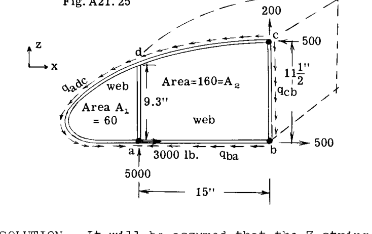

Fig. A21.25

**解法：**  
3本のストリンガーが翼梁の曲げ抵抗のすべてを受け持つと仮定する。したがって、翼のせん断流はストリンガー間で一定である。翼リブは翼外板にリベット留めされているため、リブ境界上の端部力はせん断流分布と同じであると仮定される。言い換えれば、3つのせん断流 $q_{adc}, q_{ba}, q_{cb}$ が外部荷重を平衡状態に保っている。これら3つの未知のせん断流の向きは、図 A21.25に示すように仮定される。

$q_{adc}$ を求めるために、点(b)のまわりのモーメントをとる。

$$\Sigma M_b = -2(A_1 + A_2) q_{adc} + 5000 \times 15 - 500 \times 11.5 = 0$$

$$= -2(60 + 160) q_{adc} + 75000 - 5750 = 0$$

これより、仮定した向きで $q_{adc} = 157.3 \text{ lb./in.}$ となる。

$q_{cb}$ を求めるために、 $\Sigma F_z = 0$ とする。

$$\Sigma F_z = 5000 + 200 - 157.3 \times 11.5 - 11.5 q_{cb} = 0$$

これより、 $q_{cb} = 295 \text{ lb./in.}$ となる。

$q_{ba}$ を求めるために、 $\Sigma F_x = 0$ とする。

$$\Sigma F_x = -500 + 3000 + 500 - 157.3 \times 15 - 15 q_{ba} = 0$$

これより、 $q_{ba} = 42.7 \text{ lb./in.}$ となる。

リブ境界に作用するこれらの支持外板力により、リブは平衡状態にあり、ウェブのせん断力とフランジ荷重を決定することができる。図 A21.26に示すように、補強材 ad の中心線のすぐ左側のリブ部分を自由体として考慮する。

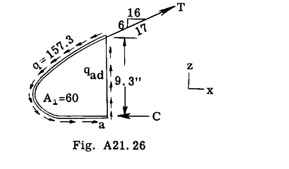

Fig. A21.26

フランジ荷重 $T$ を求めるために、点(a)のまわりのモーメントをとる。

$$\Sigma M_a = (16/17)T \times 9.3 - 157.3 \times 60 \times 2 = 0$$

これより、 $T = 2158 \text{ lb.}$ となる。

フランジ荷重 $C$ を求めるために、 $\Sigma F_x = 0$ とおくと、

$$\Sigma F_x = 2158 (16/17) - C = 0 \quad \text{これより} \quad C = 2034 \text{ lb.}$$

ウェブせん断 $q_{ad}$ を求めるために、 $\Sigma F_z = 0$ とおくと、

$$\Sigma F_z = 2158 (6/17) - 157.3 \times 9.3 + 9.3 q_{ad} = 0$$

これより、 $q_{ad} = 74.6 \text{ lb./in.}$ となる。

補強材 ad のすぐ右側のウェブにおけるせん断を求めるために、図 A21.27に示すように、補強材の取り付け線の各側でリブをカットすることによって形成される自由体を考慮する。上で求められた力はこの自由体に示されている。

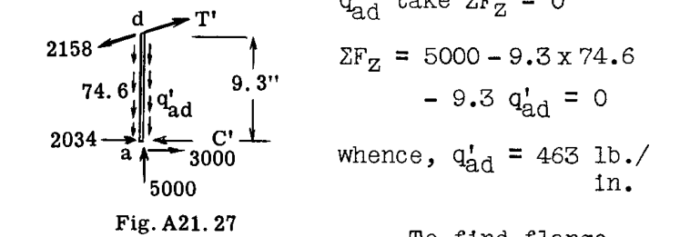

Fig. A21.27

ウェブせん断 $q'_{ad}$ を求めるために、 $\Sigma F_z = 0$ とする。

$$\Sigma F_z = 5000 - 9.3 \times 74.6 - 9.3 q'_{ad} = 0$$

これより、 $q'_{ad} = 463 \text{ lb./in.}$ となる。

接合部(a)を自由体として考慮し、フランジ荷重 $C'$ を求めるために、 $\Sigma F_x = 0$ とおくと、

$$\Sigma F_x = 2034 + 3000 - C' = 0 \quad \text{これより} \quad C' = 5034 \text{ lb.}$$

接合部(d)において、 $T'$ は明らかに $2158 \text{ lb.}$ に等しい。補強材 ad は、その(a)端で $5000 \text{ lb.}$ の圧縮荷重を支持し、2つのせん断流の和、すなわち $463 + 74.6 = 537.6 \text{ lb./in.}$ に等しい量だけ一様に減少する。

図 A21.27を考慮して得られた結果は、図 A21.28に示すように、補強材 ad のすぐ右側の断面の左側にあるリブ部分全体を処理することによっても得ることができる。

リブフランジ荷重 $T'$ を求めるために、点(a)のまわりのモーメントをとる。

$$\Sigma M_a = (16/17) T' \times 9.3 - 157.3 \times 60 \times 2 = 0$$

これより、 $T' = 2158 \text{ lb.}$ となる。

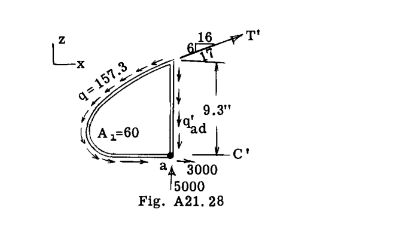

Fig. A21.28

フランジ荷重 $C'$ を求めるために、 $\Sigma F_x = 0$ とする。

$$\Sigma F_x = -C' + 3000 + 2158(16/17) = 0$$

これより、 $C' = 5034 \text{ lb.}$ となる。

$q'_{ad}$ を求めるために、 $\Sigma F_z = 0$ とする。

$$\Sigma F_z = 2158(6/17) - 157.3 \times 9.3 + 5000 - 9.3 q'_{ad} = 0$$

これより、 $q'_{ad} = 463 \text{ lb./in.}$ となる。

上記の値は、以前に得られたものと同じである。

リブフランジ荷重とウェブせん断は、線 cb のすぐ左側の断面について計算される。図 A21.29は、この断面の左側のリブの自由体を示している。

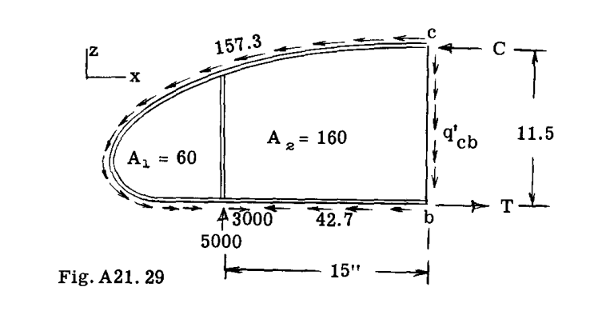

Fig. A21.29

フランジ荷重 $C$ を求めるために、点(b)のまわりのモーメントをとる。

$$\Sigma M_b = -157.3 \times 2(160 + 60) + 5000 \times 15 - 11.5 C = 0$$

これより、 $C = 500 \text{ lb.}$ となる。

フランジ荷重 $T$ を求めるために、 $\Sigma F_x = 0$ とする。

$$\Sigma F_x = 3000 - 157.3 \times 15 - 15 \times 42.7 - 500 + T = 0$$

これより、 $T = 500 \text{ lb.}$ となる。

$q'_{cb}$ を求めるために、 $\Sigma F_z = 0$ とする。

$$\Sigma F_z = 5000 - 157.3 \times 11.5 - 11.5 q'_{cb} = 0$$

これより、 $q'_{cb} = 278 \text{ lb./in.}$ となる。

上記の結果は、図 A21.29の断面 cb の右側にある力を考慮することにより、より少ない計算量で得ることもできた。

## A21.6 複数ストリンガー翼の単一セルリブの応力解析

翼にスパン方向のストリンガーが3本より多く存在する場合、セル壁には4つ以上のパネルが存在するため、前述の3本ストリンガーの例題のように静定計算によってリブ境界上のセル壁の反力を求めることはできない。

図 A21.30は、4本のスパン方向フランジ部材で構成される翼断面を示している。ボックスの4つの角に作用する集中荷重は、エンジンマウントやナセル構造からの反力、およびフラップを支持するリブからの反力を表している可能性がある。これらの荷重は翼ボックス梁の壁に分配されなければならず、そのためにはリブが必要となる。リブを設計する前に、リブに作用する曲げモーメントとせん断力を決定しなければならない。以下の計算は、その手順を示している。

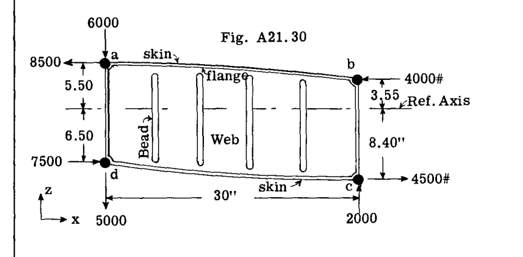

Fig. A21.30

**解法：**  
翼における $Z$ 方向の全せん断荷重は次式に等しい：  
$V_z = -6000 - 5000 + 2000 = -9000 \text{ lb}$  
また、 $V_x = -8500 + 7500 - 4000 + 4500 = -500 \text{ lb}$

リブ上の境界力は、与えられた外部力システムによるセル壁上のせん断流力システムに等しくなる。

A14章、A14.8頁、式(14)から、せん断流の式は以下の通りである：

$$q_y = - \frac{(K_3 V_x - K_1 V_z)}{\Sigma Z A} x A - \frac{(K_2 V_z - K_1 V_x)}{\Sigma Z A} z A \quad \text{--- (1)}$$

定数 $K$ は翼断面の断面特性に依存する。表 A21.1は、図心を通る $Z$ および $X$ 軸まわりの慣性モーメントおよび相乗モーメントの計算を示している。この例では、4本のストリンガー a, b, c, d が、翼の曲げ応力に抵抗する全有効材料とみなされている。

### TABLE A21.1

| 1 | 2 | 3 | 4 | 5 | 6 | 7 | 8 | 9 | 10 | 11 |
| --- | --- | --- | --- | --- | --- | --- | --- | --- | --- | --- |
| Flange No. | Area $A$ | $Z'$ | $X'$ | $AZ'$ | $AZ'^2$ | $AX'$ | $AX'^2$ | $AX'z'$ | $Z = Z' - \bar{z}$ | $X = X' - \bar{x}$ |
| a | 2.00 | 5.50 | 0 | 11.00 | 60.5 | 0 | 0 | 0 | 6.36 | -11.8 |
| b | 1.25 | 3.55 | 30 | 4.43 | 15.72 | 37.50 | 1125 | 132.9 | 4.41 | 18.2 |
| c | 1.15 | -8.40 | 30 | -9.66 | 82.20 | 34.50 | 1035 | -289.8 | -7.54 | 18.2 |
| d | 1.70 | -6.50 | 0 | -11.04 | 71.90 | 0 | 0 | 0 | -5.64 | -11.8 |
| $\Sigma$ | 6.10 |  |  | -5.27 | 230.3 | 72.00 | 2160 | -156.9 |  |  |

$$\bar{z} = \Sigma AZ' / \Sigma A = -5.27 / 6.10 = -0.865 \text{ in.}$$

$$\bar{x} = \Sigma AX' / \Sigma A = 72.0 / 6.10 = 11.8 \text{ in.}$$

図心軸 $x$ および $z$ まわりの慣性モーメント：

$$I_x = 230.3 - 6.10 \times .865^2 = 225.8$$

$$I_z = 2160 - 6.10 \times 11.8^2 = 1310$$

$$I_{xz} = -156.9 - 6.10 \times (-0.865) \times 11.8 = -94.7$$

翼断面の特性が既知となったので、定数 $K$ を計算できる。

$$K_1 = I_{xz} / (I_x I_z - I_{xz}^2)$$

$$= -94.7 / (225.8 \times 1310 - 94.7^2) =$$

$$-94.7 / 286700 = -0.00033$$

$$K_2 = I_z / 286700 = 1310 / 286700 = 0.00456$$

$$K_3 = I_x / 286700 = 225.8 / 286700 = 0.000786$$

式(1)に代入すると、

$$q_y = - [0.000786(-500) - (-0.00033)(-9000)] \Sigma x A - [0.00456(-9000) - (-0.00033)(-500)] \Sigma z A$$

これより、

$$q_y = 3.363 \Sigma x A + 41.205 \Sigma z A \quad \text{--- (2)}$$

セル壁の任意の点におけるせん断流は未知であるため、ウェブ ad においてゼロであると仮定するか、または図 A21.31に示すようにウェブがカットされていると仮定する。静的なせん断流は以下のように求められる。

$$q_{ab} = 3.363(-11.8)(2.0) + 41.205 \times 6.36 \times 2 = 444 \text{ lb./in.}$$

$$q_{bc} = 444 + 3.363 \times 18.2 \times 1.25 + 41.205 \times 4.41 \times 1.25 = 748 \text{ lb./in.}$$

$$q_{cd} = 748 + 3.363 \times 18.2 \times 1.15 + 41.205(-7.54)(1.15) = 461 \text{ lb./in.}$$

これらのせん断流は図 A21.31にプロットされている。せん断流の向きについては A14章を参照されたい。

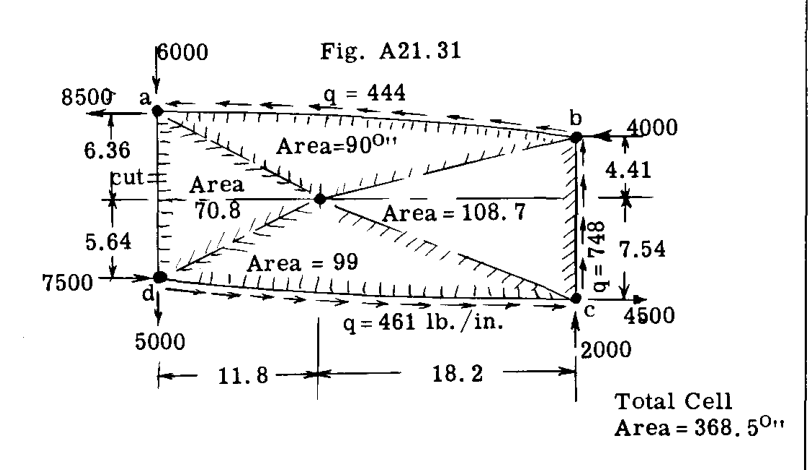

Fig. A21.31

リブの面内にある力のモーメントを計算する。

梁断面の重心まわりのモーメントをとる（図 A21.31を参照）：

$$\Sigma M_{\text{c.g.}} = -11000 \times 11.8 - 8500 \times 6.36 - 7500 \times 5.65 - 4000 \times 4.41 - 4500 \times 7.54 - 2000 \times 18.2 - 444 \times 2 \times 90 - 748 \times 2 \times 108.7 - 461 \times 2 \times 99 = -648400 \text{ in.lb.}$$

平衡のために $\Sigma M_{\text{c.g.}}$ はゼロでなければならない。したがって、648400 in.lb. のモーメントを生じさせるような、リブ外周に作用する一定の流動せん断 $q_1$ が必要である。

$$q_1 = \frac{M}{2A} = \frac{648400}{2 \times 368.5} = 880 \text{ lb./in.}$$

（注：368.5 = セルの全断面積）

このせん断流を図 A21.31のものに加算すると、図 A21.32の合成力システムが得られる。リブに対する梁セル壁の反力が決定されたので、リブの曲げモーメントとせん断力を計算することができる。

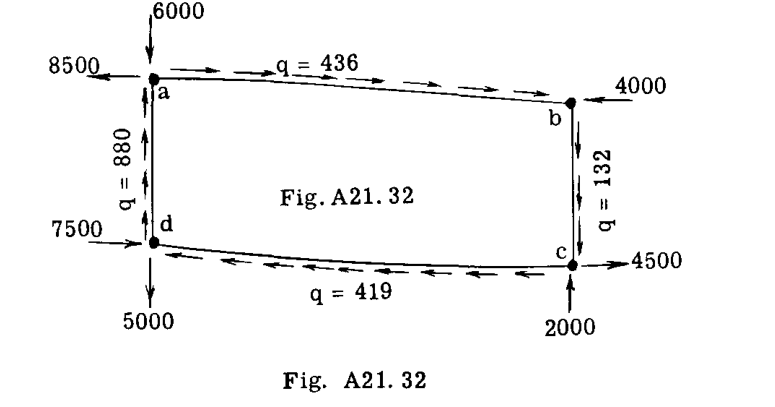

Fig. A21.32

説明のために、梁の重心を通るリブ断面 B-B を考える。図 A21.33は、断面 B-B の左側にある隔壁部分の自由体を示している。

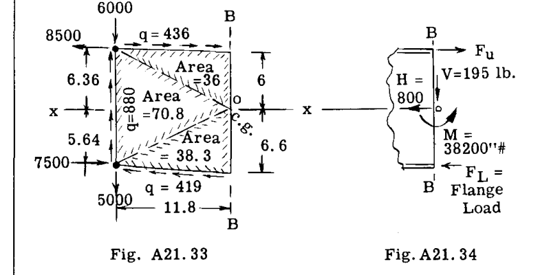

Fig. A21.33

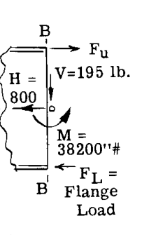

Fig.A21.34

断面 B-B におけるモーメントは、点(O)を基準とする：

$$\Sigma M_O = -11000 \times 11.8 - 8500 \times 6.36 - 7500 \times 5.65 + 436 \times 2 \times 36 + 880 \times 2 \times 70.8 + 419 \times 2 \times 38.3 = -38200 \text{ in.lb.}$$